# Summary Plots and Statistics for HICEAS 2017 Odontocete Events

#### Event ID: 1705214 | Species: 33

Time: 2017-10-09 23:13UTC to 2017-10-10 01:17UTC

Event contains 42203 original clicks, **2660 valid clicks** after filtering.

Event contains **840 whistles**.

##### Click plots and table

SNR histogram includes all filtered clicks. Other plots contain only clicks with SNR >= 15 dB (**n = 2473 clicks**) .

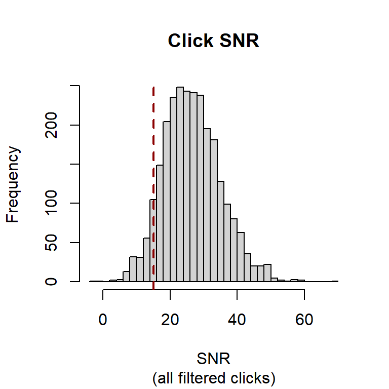

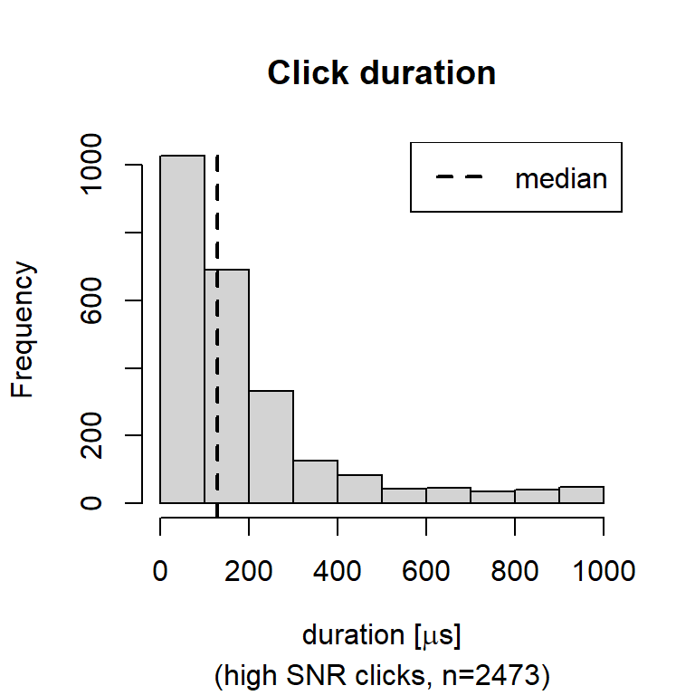

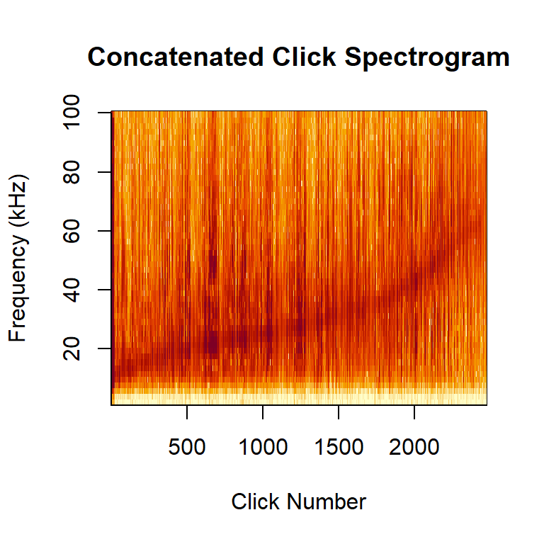

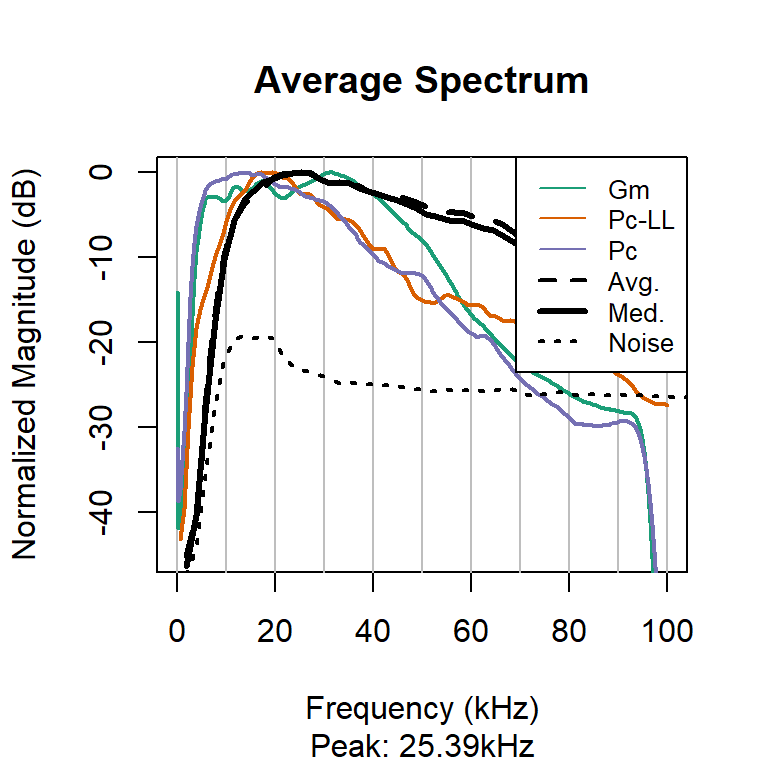

Median statistics for 2473 high SNR clicks with SNR >= 15 dB.

| parameter | value |
| --- | --- |
| Median Peak Frequency [kHz] | 24 |
| Median 3dB Center Frequency [kHz] | 23.6 |
| Median 10dB Center Frequency [kHz] | 24.3 |
| Median 3dB Bandwidth [kHz] (lower-upper) | 2.62 (21.7 - 25.5) |
| Median 10dB Bandwidth [kHz] (lower-upper) | 10.6 (16.5 - 29.8) |
| Median duration [μs] (25-75 percentile) | 130 (48 - 230) |

##### Whistle plots and table

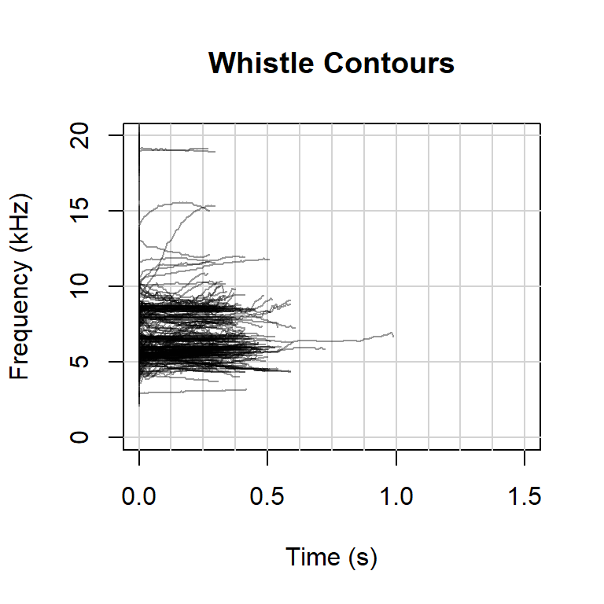

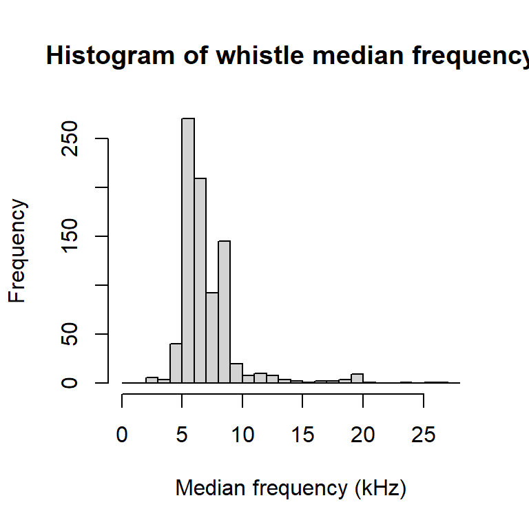

Median statistics for n = 840 whistles.

[output not shown]

#### Event ID: 1705276 | Species: 33

Time: 2017-11-01 02:40UTC to 2017-11-01 04:40UTC

Event contains 46466 original clicks, **3804 valid clicks** after filtering.

Event contains **2963 whistles**.

##### Click plots and table

SNR histogram includes all filtered clicks. Other plots contain only clicks with SNR >= 15 dB (**n = 3574 clicks**) .

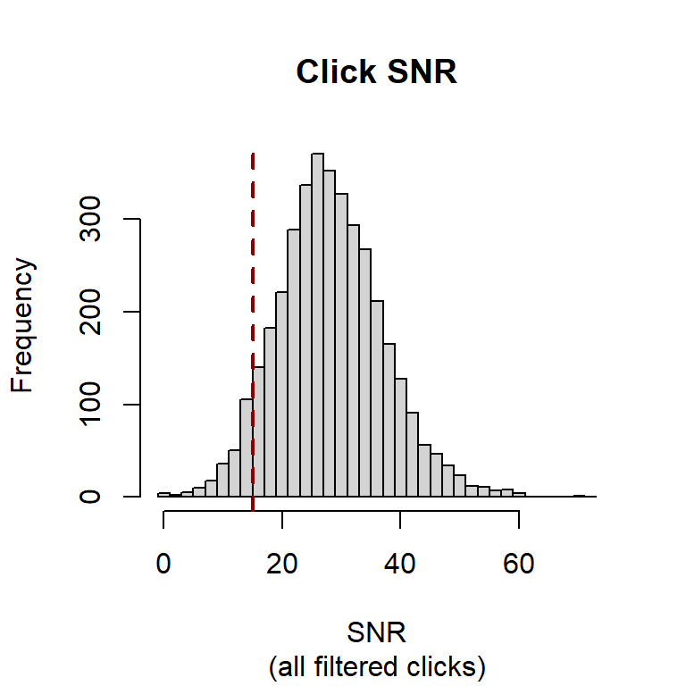

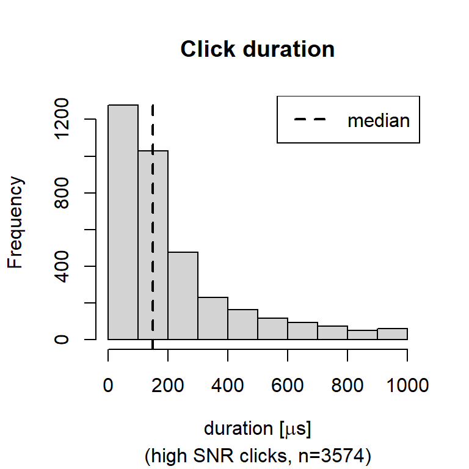

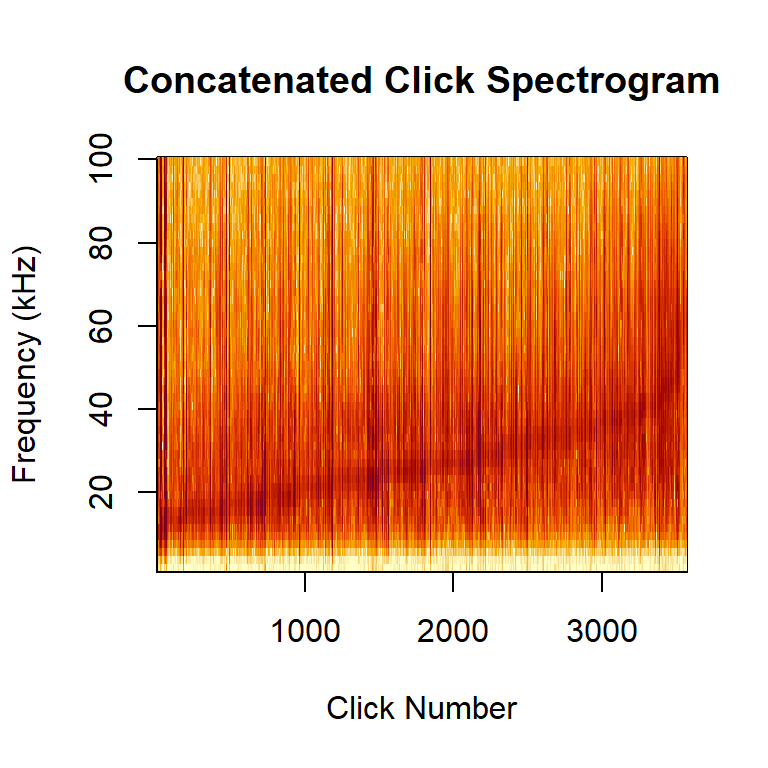

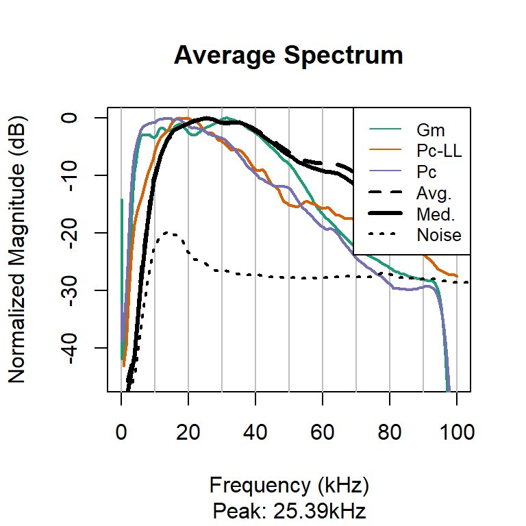

Median statistics for 3574 high SNR clicks with SNR >= 15 dB.

| parameter | value |
| --- | --- |
| Median Peak Frequency [kHz] | 22.4 |
| Median 3dB Center Frequency [kHz] | 22.4 |
| Median 10dB Center Frequency [kHz] | 22.2 |
| Median 3dB Bandwidth [kHz] (lower-upper) | 2.31 (20.8 - 23.8) |
| Median 10dB Bandwidth [kHz] (lower-upper) | 8.97 (16.8 - 27.2) |
| Median duration [μs] (25-75 percentile) | 150 (100 - 270) |

##### Whistle plots and table

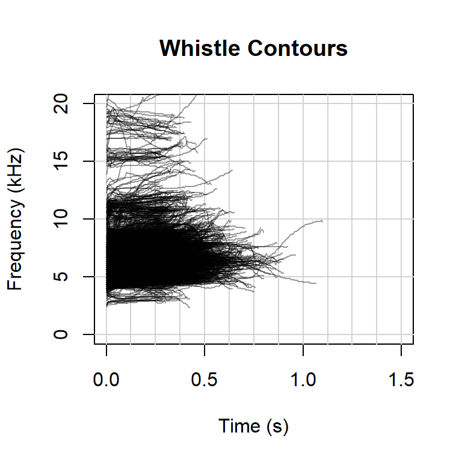

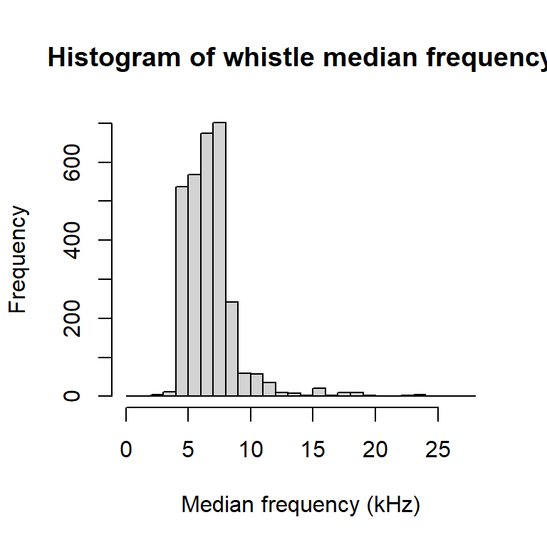

Median statistics for n = 2963 whistles.

| parameter | value |
| --- | --- |
| Median begin frequency [kHz] | 5.79 |
| Median end frequency [kHz] | 6.81 |
| Median mean frequency [kHz] (SD) | 6.36 (0.26) |
| Median duration [s] | 0.369 |
| Median frequency range [kHz] (min-max) | 1.03 (5.64 - 7.03) |

#### Event ID: 1705279 | Species: 33

Time: 2017-11-02 23:15UTC to 2017-11-03 01:41UTC

Event contains 79141 original clicks, **7495 valid clicks** after filtering.

Event contains **9266 whistles**.

##### Click plots and table

SNR histogram includes all filtered clicks. Other plots contain only clicks with SNR >= 15 dB (**n = 7031 clicks**) .

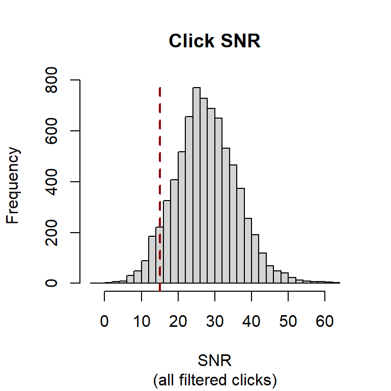

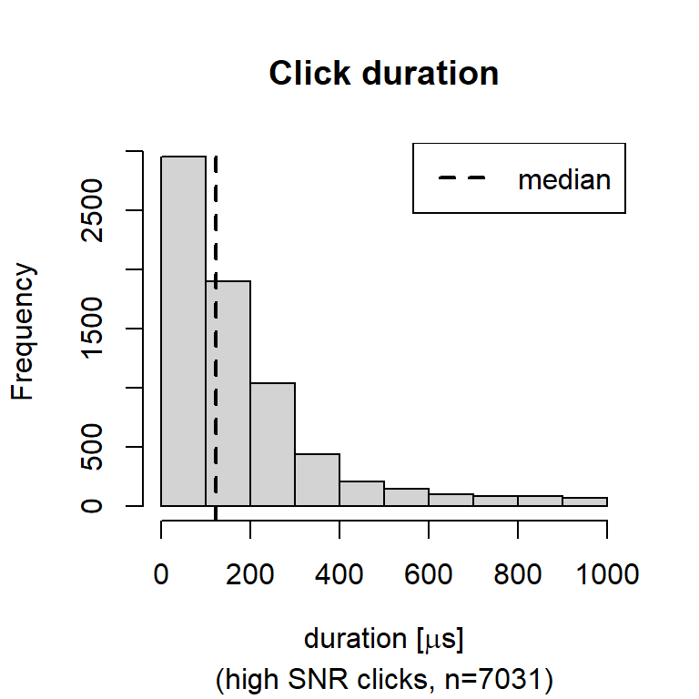

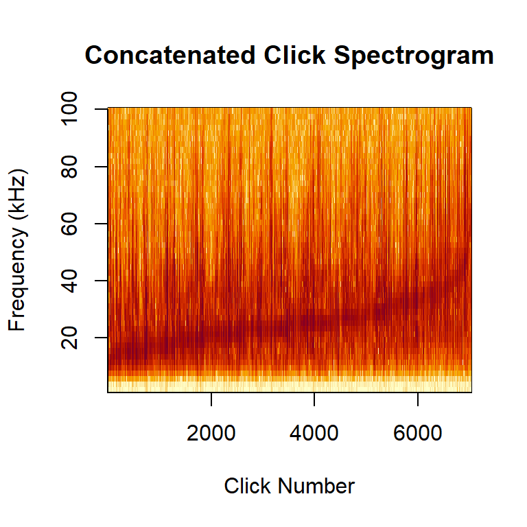

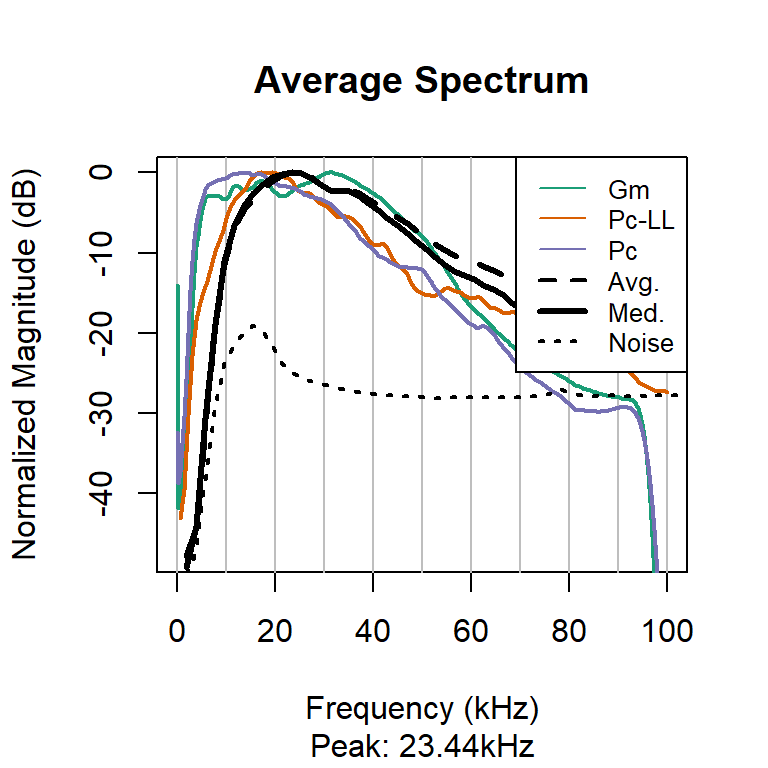

Median statistics for 7031 high SNR clicks with SNR >= 15 dB.

| parameter | value |
| --- | --- |
| Median Peak Frequency [kHz] | 21.6 |
| Median 3dB Center Frequency [kHz] | 21.2 |
| Median 10dB Center Frequency [kHz] | 21.7 |
| Median 3dB Bandwidth [kHz] (lower-upper) | 2.57 (19.4 - 23.1) |
| Median 10dB Bandwidth [kHz] (lower-upper) | 11 (14.9 - 27.6) |
| Median duration [μs] (25-75 percentile) | 124 (100 - 232) |

##### Whistle plots and table

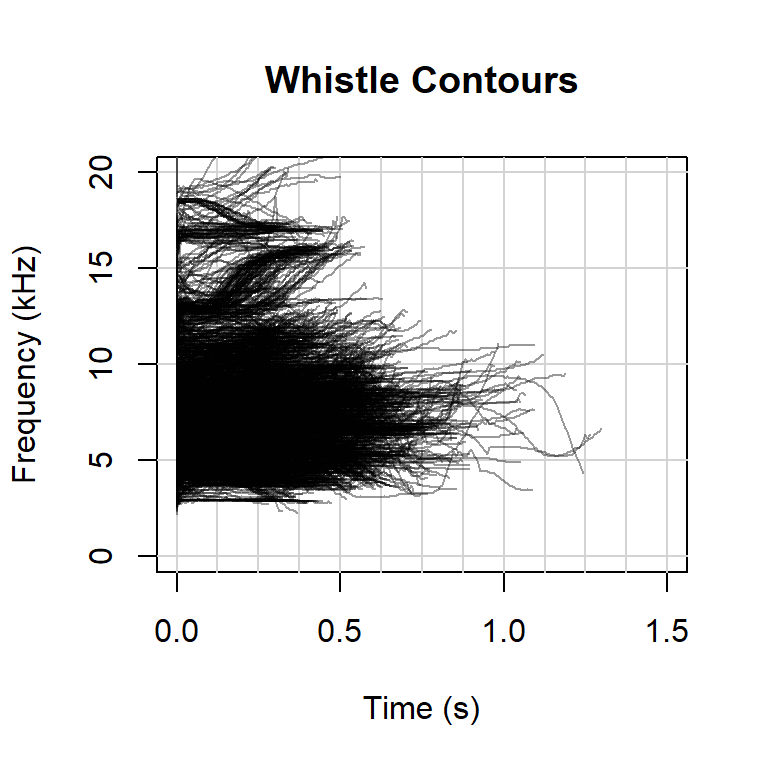

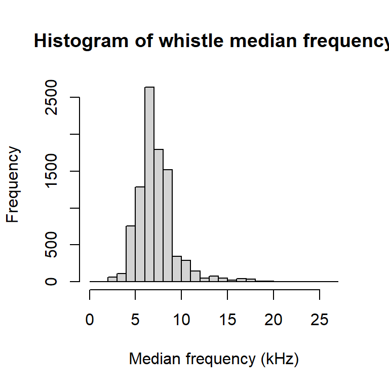

Median statistics for n = 9266 whistles.

| parameter | value |
| --- | --- |
| Median begin frequency [kHz] | 6.59 |
| Median end frequency [kHz] | 7.25 |
| Median mean frequency [kHz] (SD) | 6.94 (0.29) |
| Median duration [s] | 0.273 |
| Median frequency range [kHz] (min-max) | 1.10 (6.30 - 7.69) |

#### Event ID: 1705280 | Species: 33

Time: 2017-11-03 01:41UTC to 2017-11-03 03:02UTC

Event contains 30872 original clicks, **2248 valid clicks** after filtering.

Event contains **3556 whistles**.

##### Click plots and table

SNR histogram includes all filtered clicks. Other plots contain only clicks with SNR >= 15 dB (**n = 2114 clicks**) .

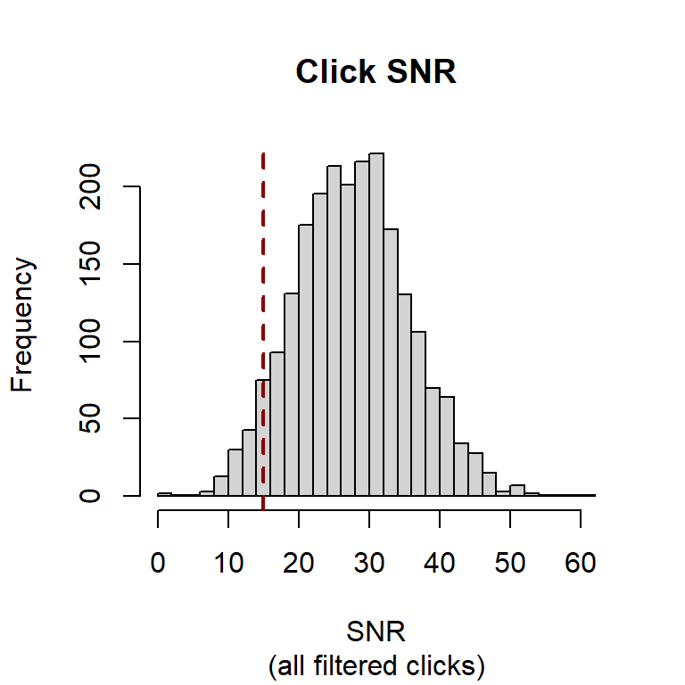

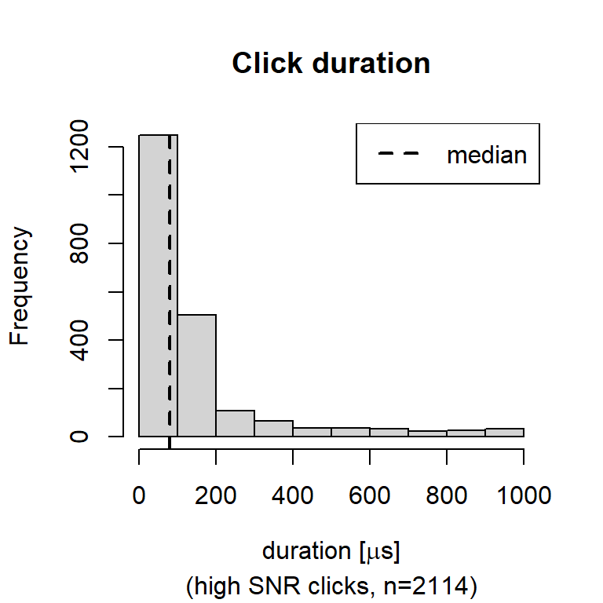

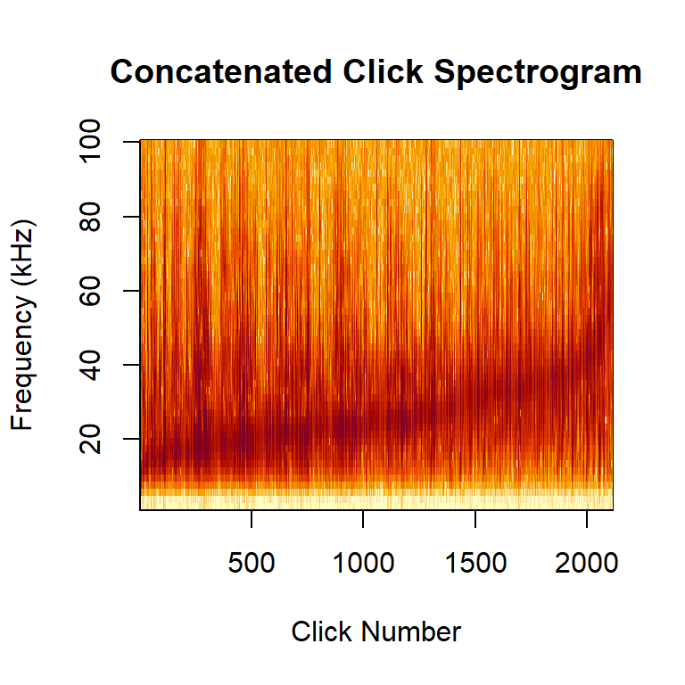

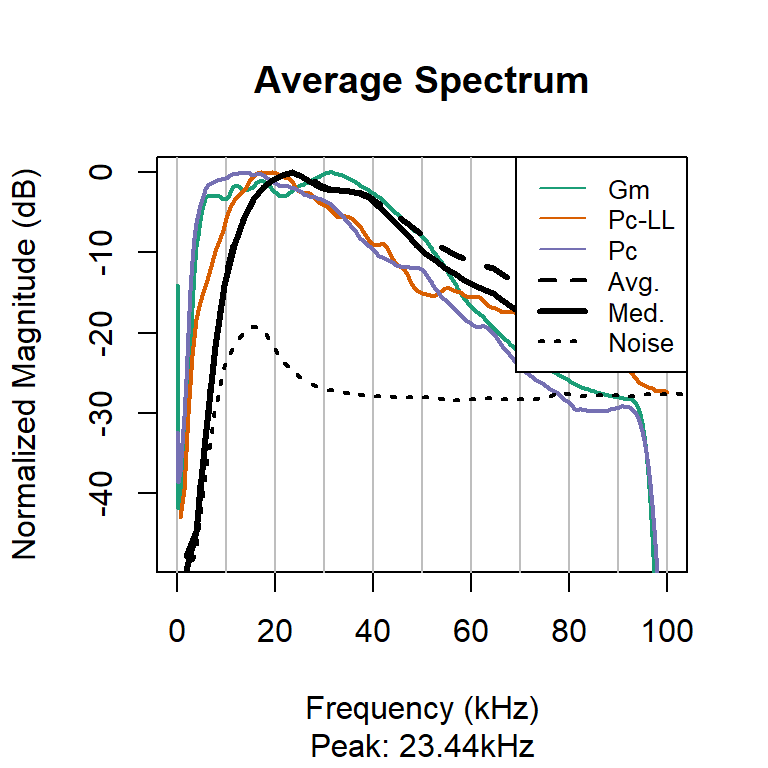

Median statistics for 2114 high SNR clicks with SNR >= 15 dB.

| parameter | value |
| --- | --- |
| Median Peak Frequency [kHz] | 22.6 |
| Median 3dB Center Frequency [kHz] | 21.7 |
| Median 10dB Center Frequency [kHz] | 22.9 |
| Median 3dB Bandwidth [kHz] (lower-upper) | 2.82 (19.6 - 24) |
| Median 10dB Bandwidth [kHz] (lower-upper) | 15.3 (14.8 - 30.1) |
| Median duration [μs] (25-75 percentile) | 81 (38 - 146) |

##### Whistle plots and table

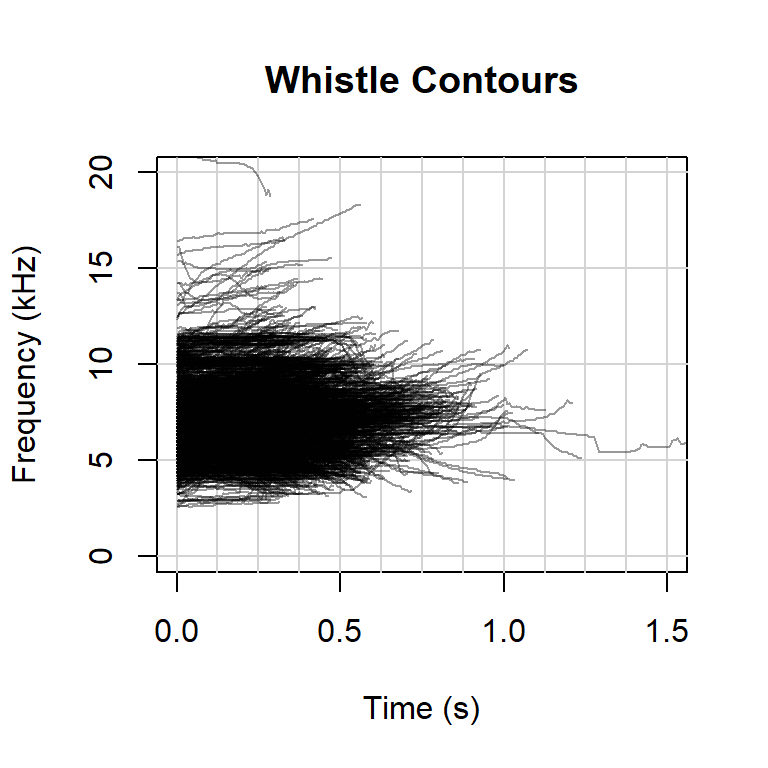

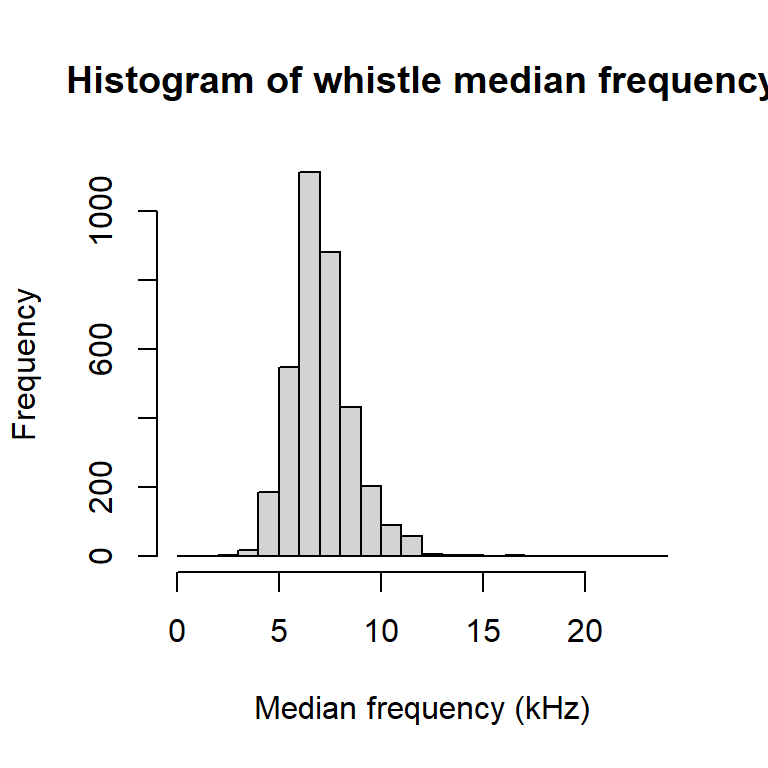

Median statistics for n = 3556 whistles.

[output not shown]

#### Event ID: 1705308 | Species: 33

Time: 2017-11-07 17:02UTC to 2017-11-07 19:44UTC

Event contains 55434 original clicks, **5574 valid clicks** after filtering.

Event contains **4911 whistles**.

##### Click plots and table

SNR histogram includes all filtered clicks. Other plots contain only clicks with SNR >= 15 dB (**n = 5381 clicks**) .

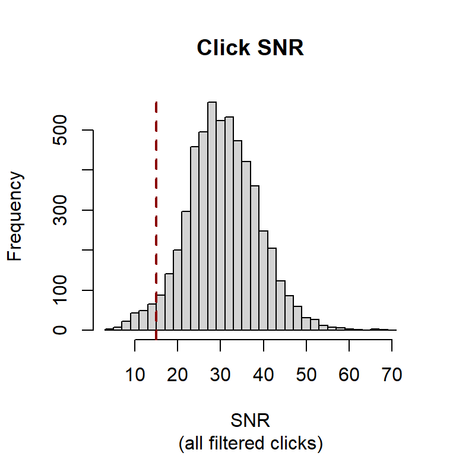

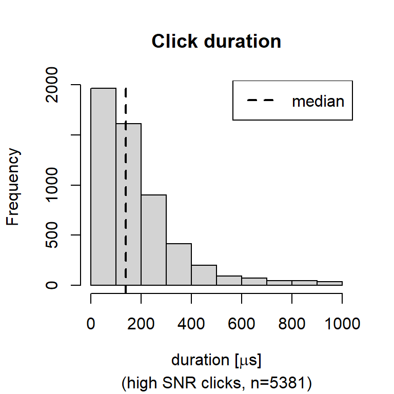

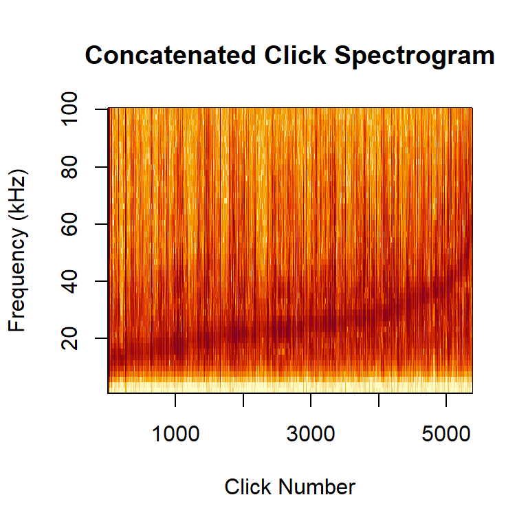

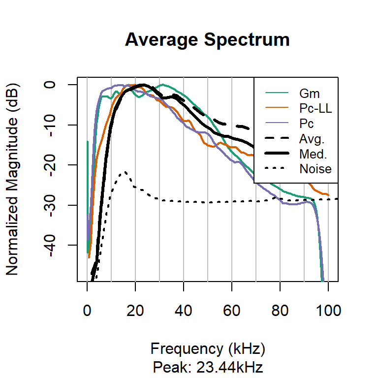

Median statistics for 5381 high SNR clicks with SNR >= 15 dB.

| parameter | value |
| --- | --- |
| Median Peak Frequency [kHz] | 21.6 |
| Median 3dB Center Frequency [kHz] | 21.1 |
| Median 10dB Center Frequency [kHz] | 21.1 |
| Median 3dB Bandwidth [kHz] (lower-upper) | 3.13 ( 19 - 23.3) |
| Median 10dB Bandwidth [kHz] (lower-upper) | 11.5 ( 14 - 27.3) |
| Median duration [μs] (25-75 percentile) | 140 (100 - 238) |

##### Whistle plots and table

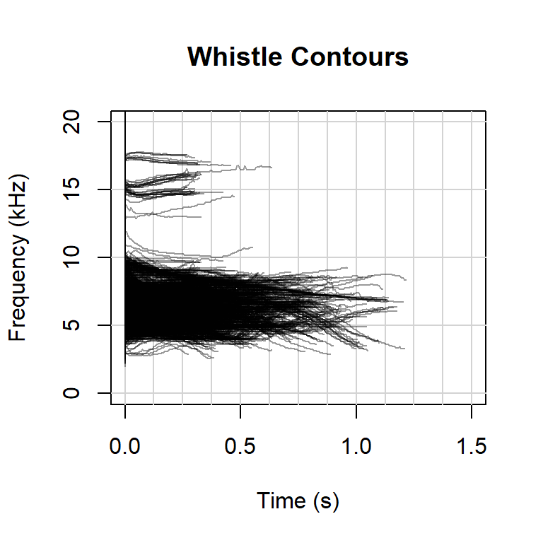

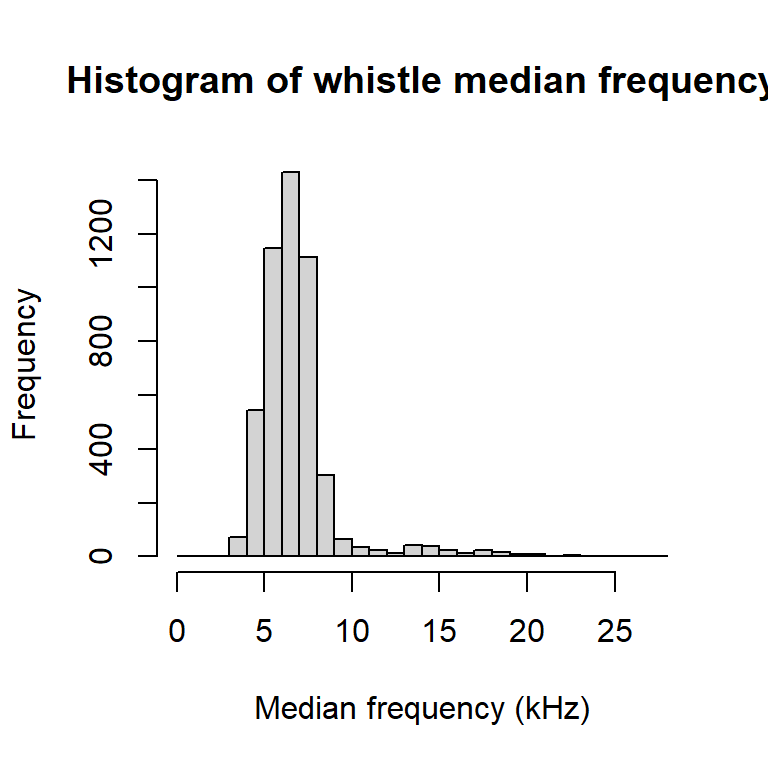

Median statistics for n = 4911 whistles.

[output not shown]

#### Event ID: 1705416 | Species: 33

Time: 2017-11-30 22:47UTC to 2017-11-30 23:53UTC

Event contains 6697 original clicks, **714 valid clicks** after filtering.

Event contains **562 whistles**.

##### Click plots and table

SNR histogram includes all filtered clicks. Other plots contain only clicks with SNR >= 15 dB (**n = 695 clicks**) .

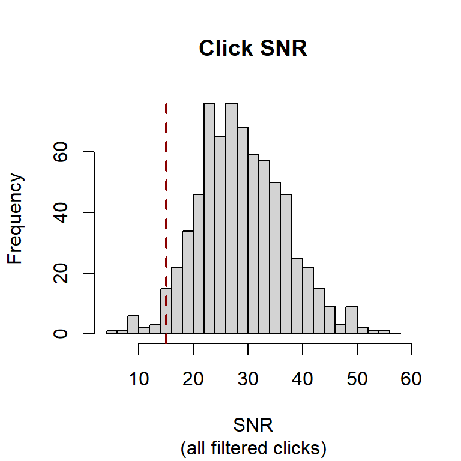

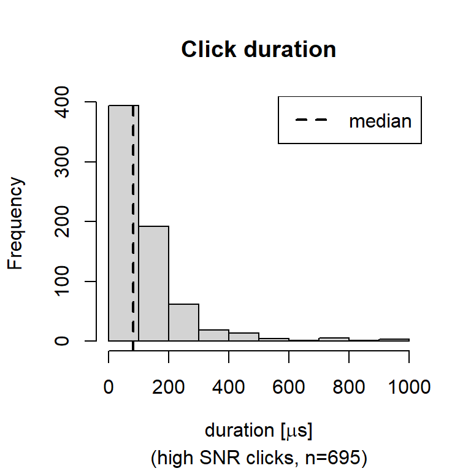

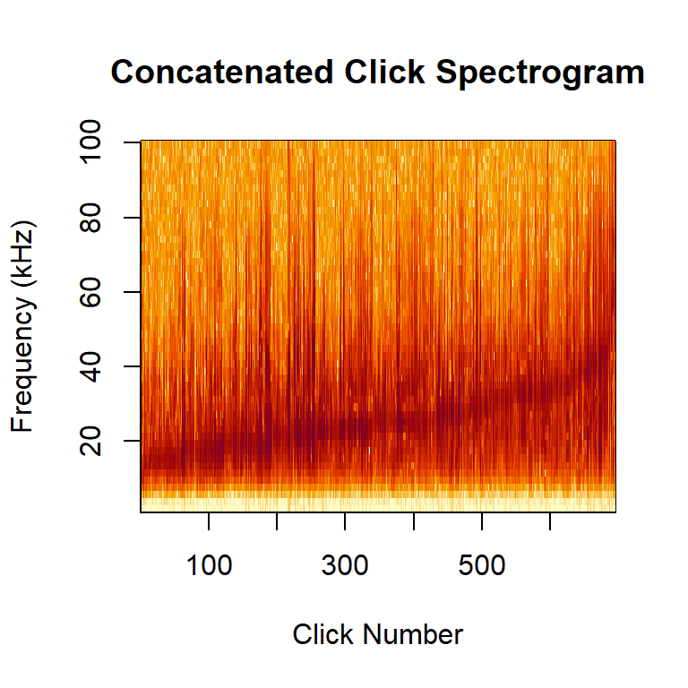

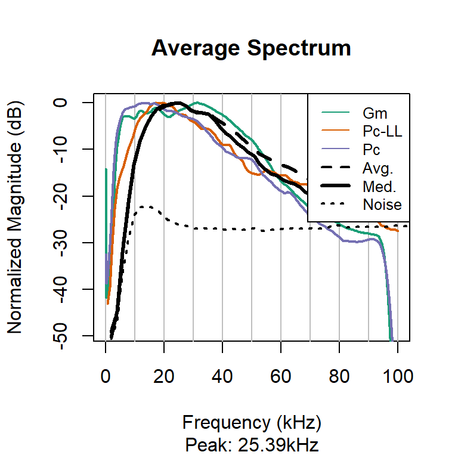

Median statistics for 695 high SNR clicks with SNR >= 15 dB.

| parameter | value |
| --- | --- |
| Median Peak Frequency [kHz] | 21.2 |
| Median 3dB Center Frequency [kHz] | 21.7 |
| Median 10dB Center Frequency [kHz] | 21.7 |
| Median 3dB Bandwidth [kHz] (lower-upper) | 3.26 (19.9 - 23.6) |
| Median 10dB Bandwidth [kHz] (lower-upper) | 12.1 (14.7 - 28) |
| Median duration [μs] (25-75 percentile) | 82 (30 - 150) |